# Lecture 4: Distribution of Random Variables

2015-07-22

## Overview

## Today's Material

- Random Variables
- Distributions

## Where we are

## Goals

- Describe and characterize random variables
- Employ samping methods in R
- Know what a distribution is

## Random variables

## Random variables

- A **random variable** is a variable whose value is subject to variations due to chance
- The random variables that we study will come in two varieties, **discrete** or **continuous**.
- Discrete random variable are random variables that take on only a countable number of possibilities.
- \(P(X = k)\)
- Continuous random variable can take any value on the real line or some subset of the real line.
- \(P(X \in A)\)
- In the real world, we often blur the lines between discrete and continuous

## Examples of variables that can be thought of as random variables

- The \((0-1)\) outcome of the flip of a coin
- The outcome from the roll of a die
- The BMI of a subject four years after a baseline measurement
- The hypertension status of a subject randomly drawn from a population
- Difference between students' beginning-of-year and end-or-year test scores

## Probability Mass Function

A probability mass function (PMF) evaluated at a value corresponds to the probability that a random variable takes that value. To be a valid pmf a function, \(p\), must satisfy

1. \(p(x) \geq 0\) for all \(x\)
2. \(\sum_{x} p(x) = 1\)

The sum is taken over all of the possible values for \(x\).

## Example

Let \(X\) be the result of a coin flip where \(X=0\) represents tails and \(X = 1\) represents heads. \[ p(x) = (1/2)^{x} (1/2)^{1-x} ~~\mbox{ for }~~x = 0,1 \] Suppose that we do not know whether or not the coin is fair; Let \(\theta\) be the probability of a head expressed as a proportion (between 0 and 1). \[ p(x) = \theta^{x} (1 - \theta)^{1-x} ~~\mbox{ for }~~x = 0,1 \]

## Probability Density Function

A probability density function (pdf), is a function associated with a continuous random variable

*Areas under pdfs correspond to probabilities for that random variable*

To be a valid pdf, a function \(f\) must satisfy

1. \(f(x) \geq 0\) for all \(x\)
2. The area under \(f(x)\) is one.

## Caveat for continuous pdfs

-One tricky aspect to remember is that for a continuous pdf, the probability that x takes any one particular value is undefined

-Since we assume that *x* is continuous, then it can take ANY real value

-Thus, there is effectively 0 chance that *x* will take any one value (e.g., x = 0.124556), since there are an infinite number of possible values (e.g., x = 0.124567 instead)

-Because of this, for continuous pdfs we use <=, >=, <, or >

## CDF and survival function

- The **cumulative distribution function** (CDF) of a random variable \(X\) is defined as the function \[ F(x) = P(X \leq x) \]
- This definition applies regardless of whether \(X\) is discrete or continuous.
- The **survival function** of a random variable \(X\) is defined as \[ S(x) = P(X > x) \]
- Notice that \(S(x) = 1 - F(x)\)
- For continuous random variables, the PDF is the derivative of the CDF

## Quantiles

- The \(\alpha^{th}\) **quantile** of a distribution with distribution function \(F\) is the point \(x_\alpha\) so that \[ F(x_\alpha) = \alpha \]
- A **percentile** is simply a quantile with \(\alpha\) expressed as a percent
- The **median** is the \(50^{th}\) percentile

## Expected value

## Expected values

- The **expected value** or **mean** of a random variable is the center of its distribution

-Think of EV as the place where the "scale" is balanced 50/50

- For discrete random variable \(X\) with PMF \(p(x)\), it is defined as follows \[ E[X] = \sum_x xp(x). \] where the sum is taken over the possible values of \(x\)
- \(E[X]\) represents the center of mass of a collection of locations and weights, \(\{x, p(x)\}\)

## Example

### Find the center of mass of the bars

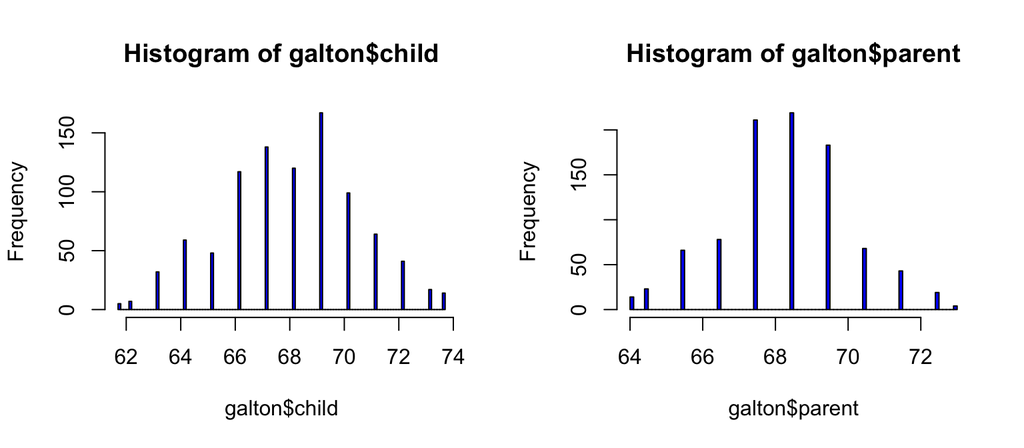

## Example

- Suppose a coin is flipped and \(X\) is declared \(0\) or \(1\) corresponding to a head or a tail, respectively
- What is the expected value of \(X\)? \[ E[X] = .5 \times 0 + .5 \times 1 = .5 \]

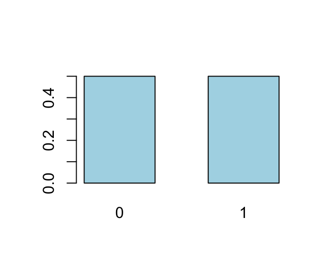

- Suppose that a die is rolled and \(X\) is the number face up
- What is the expected value of \(X\)? \[ E[X] = 1 \times \frac{1}{6} + 2 \times \frac{1}{6} +\\ 3 \times \frac{1}{6} + 4 \times \frac{1}{6} + 5 \times \frac{1}{6} + 6 \times \frac{1}{6} = 3.5 \] -What if we draw this like in the previous slide?

## Continuous random variables

- For a continuous random variable, \(X\), with density, \(f\), the expected value is defined as follows \[ E[X] = \mbox{the area under the function}~~~ t f(t) \]
- This definition borrows from the definition of center of mass for a continuous body

## Example

- Consider a density where \(f(x) = 1\) for \(x\) between zero and one
- (Is this a valid density?)
- Suppose that \(X\) follows this density; what is its expected value?

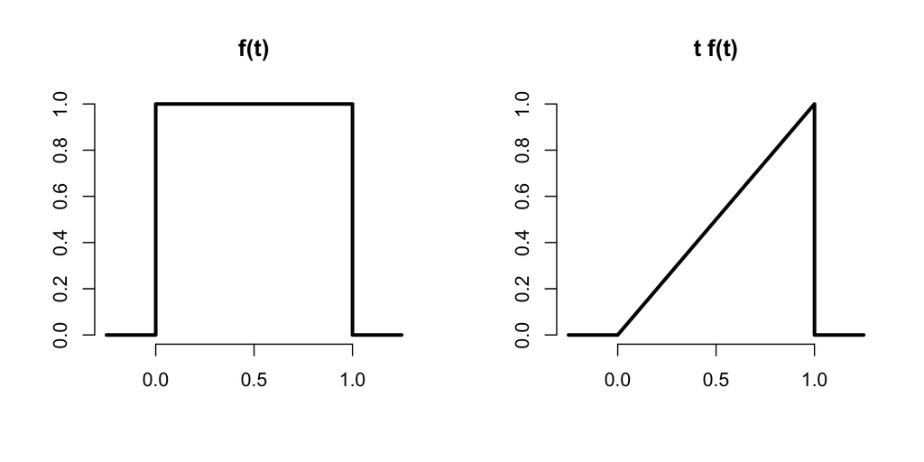

## Example

1. Let \(X_i\) for \(i=1,\ldots,n\) be a collection of random variables, each from a distribution with mean \(\mu\)
2. Calculate the expected value of the sample average of the \(X_i\) \[ \begin{eqnarray*} E\left[ \frac{1}{n}\sum_{i=1}^n X_i\right] & = & \frac{1}{n} E\left[\sum_{i=1}^n X_i\right] \\ & = & \frac{1}{n} \sum_{i=1}^n E\left[X_i\right] \\ & = & \frac{1}{n} \sum_{i=1}^n \mu = \mu. \end{eqnarray*} \]
- Therefore, the expected value of the **sample mean** is the population mean that it's trying to estimate
- When the expected value of an estimator is what its trying to estimate, we say that the estimator is **unbiased**
- What does "bias" mean then in statistics?

## Uncertainty and random variables

## Measures of dispersion

-Much of what we have discussed so far relates to measures of central tendency

-We also are interested in describing our level of certainty about a parameter estimate

-Measures of dispersion quantify the uncertainty of an estimate

## Variance

- The variance of a random variable is a measure of *spread*
- If \(X\) is a random variable with mean \(\mu\), the variance of \(X\) is defined as

\[ Var(X) = E[(X - \mu)^2] \]

the expected (squared) distance from the mean

- Densities with a higher variance are more spread out than densities with a lower variance

## Example

- What's the variance from the result of a toss of a die?
- \(E[X] = 3.5\)
- \(E[X^2] = 1 ^ 2 \times \frac{1}{6} + 2 ^ 2 \times \frac{1}{6} + 3 ^ 2 \times \frac{1}{6} + 4 ^ 2 \times \frac{1}{6} + 5 ^ 2 \times \frac{1}{6} + 6 ^ 2 \times \frac{1}{6} = 15.17\)
- \(Var(X) = E[X^2] - E[X]^2 \approx 2.92\)

## Example

- What's the variance from the result of the toss of a coin with probability of heads (1) of \(p\)?
- \(E[X] = 0 \times (1 - p) + 1 \times p = p\)
- \(E[X^2] = E[X] = p\)

\[Var(X) = E[X^2] - E[X]^2 = p - p^2 = p(1 - p)\]

## Distributions with increasing variance

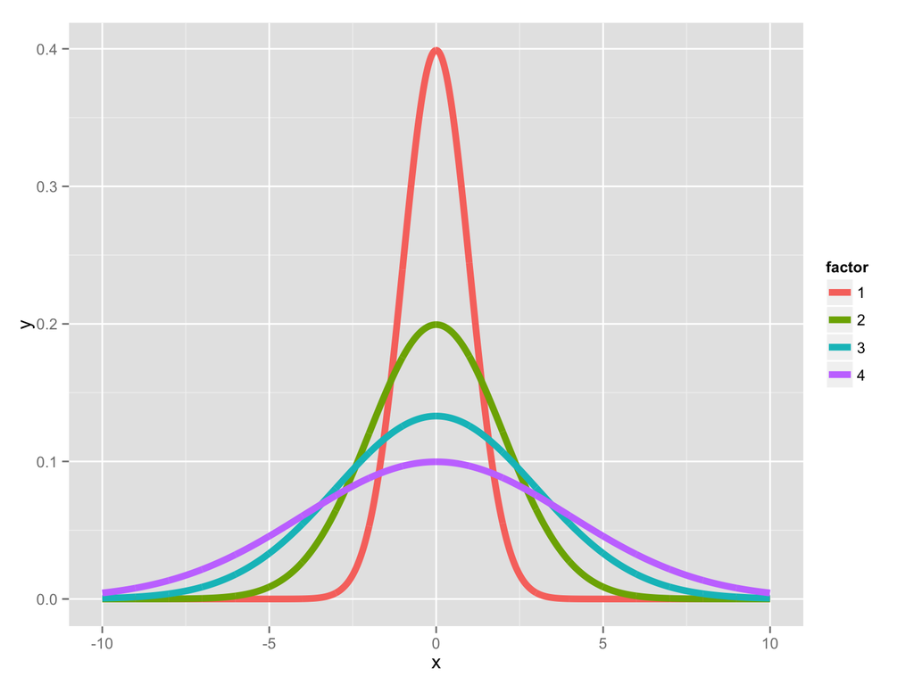

## The sample variance

- The sample variance is \[ S^2 = \frac{\sum_{i=1} (X_i - \bar X)^2}{n-1} \] (almost, but not quite, the average squared deviation from the sample mean)
- It is also a random variable
- It has an associate population distribution
- Its expected value is the population variance
- Its distribution gets more concentrated around the population variance with more data
- Its square root is the sample standard deviation

## Standard Deviation

- Convenient computational form \[ Var(X) = E[X^2] - E[X]^2 \]
- If \(a\) is constant then \(Var(aX) = a^2 Var(X)\)
- The square root of the variance is called the **standard deviation**
- The standard deviation has the same units as \(X\)

## Covariance

- The **covariance** between two random variables \(X\) and \(Y\) is defined as \[ Cov(X, Y) = E[(X - \mu_x)(Y - \mu_y)] = E[X Y] - E[X]E[Y] \]
- The following are useful facts about covariance
1. \(Cov(X, Y) = Cov(Y, X)\)
2. \(Cov(X, Y)\) can be negative or positive
3. \(|Cov(X, Y)| \leq \sqrt{Var(X) Var(y)}\)

## 'iid' random variables

- Random variables are said to be 'iid' if they are independent and identically distributed
- For instance, we might assume that dice rolls are iid
- iid random variables are the default model for random samples
- Many of the important theories of statistics are founded on assuming that variables are iid

-We have already discussed distributions to some extent (e.g., PDF)

-There are many different probability distribution forms

-For 8120, we will primarily focus on the normal distribution

## Normal Distribution

## Facts about the normal density

- If \(X \sim \mbox{N}(\mu,\sigma^2)\) the \(Z = \frac{X -\mu}{\sigma}\) is standard normal
- If \(Z\) is standard normal \[X = \mu + \sigma Z \sim \mbox{N}(\mu, \sigma^2)\]
- The non-standard normal density is \[\phi\{(x - \mu) / \sigma\}/\sigma\]

## More facts about the normal density

1. Approximately \(68\%\), \(95\%\) and \(99\%\) of the normal density lies within \(1\), \(2\) and \(3\) standard deviations from the mean, respectively
2. \(-1.28\), \(-1.645\), \(-1.96\) and \(-2.33\) are the \(10^{th}\), \(5^{th}\), \(2.5^{th}\) and \(1^{st}\) percentiles of the standard normal distribution respectively
3. By symmetry, \(1.28\), \(1.645\), \(1.96\) and \(2.33\) are the \(90^{th}\), \(95^{th}\), \(97.5^{th}\) and \(99^{th}\) percentiles of the standard normal distribution respectively

## Question

- What is the \(95^{th}\) percentile of a \(N(\mu, \sigma^2)\) distribution?
- Quick answer in R `qnorm(.95, mean = mu, sd = sd)`
- We want the point \(x_0\) so that \(P(X \leq x_0) = .95\)

## Other properties

- The normal distribution is symmetric and peaked about its mean (therefore the mean, median and mode are all equal)
- The square of a *standard normal* random variable follows what is called **chi-squared** distribution
- The exponent of a normally distributed random variables follows what is called the **log-normal** distribution
- As we will see later, many random variables, properly normalized, *limit* to a normal distribution

## The 'Normal model'

- Bell Shaped: unimodal, symmetric
- A Normal model for every mean and standard deviation.
- \(\mu\) (read “mew”) represents the population mean.
- \(\sigma\) (read “sigma”) represents the population standard deviation.
- \(N(\mu, \sigma)\) represents a Normal model with mean m and standard deviation s.

\[f(x)\quad =\quad \frac { 1 }{ \sigma \sqrt { 2\pi } } { e }^{ -\frac { { \left( x-\mu \right) }^{ 2 } }{ { 2\sigma }^{ 2 } } }\]

- \(N(0, 1)\) is called the standard Normal model, or the standard Normal distribution.

## Non-normal distributions

## The Bernoulli distribution

- The **Bernoulli distribution** arises as the result of a binary outcome
- Bernoulli random variables take (only) the values 1 and 0 with probabilities of (say) \(p\) and \(1-p\) respectively
- The PMF for a Bernoulli random variable \(X\) is \[P(X = x) = p^x (1 - p)^{1 - x}\]
- The mean of a Bernoulli random variable is \(p\) and the variance is \(p(1 - p)\)
- If we let \(X\) be a Bernoulli random variable, it is typical to call \(X=1\) as a "success" and \(X=0\) as a "failure"

## Possible likelihoods for a small n

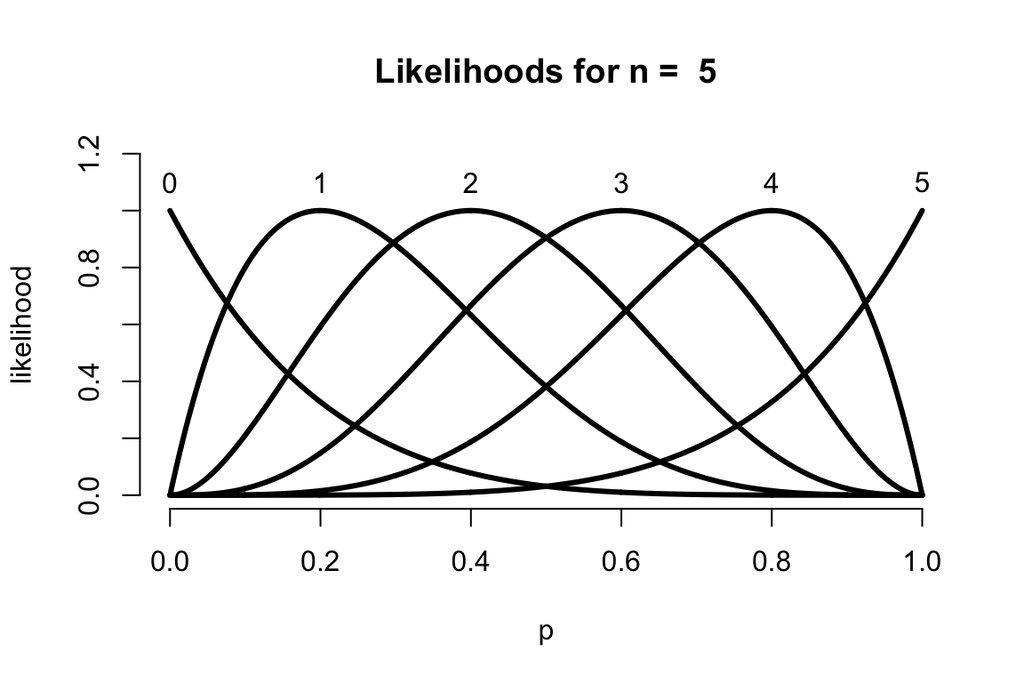

## Binomial trials

- The *binomial random variables* are obtained as the sum of iid Bernoulli trials
- In specific, let \(X_1,\ldots,X_n\) be iid Bernoulli\((p)\); then \(X = \sum_{i=1}^n X_i\) is a binomial random variable
- The binomial mass function is \[ P(X = x) = \left( \begin{array}{c} n \\ x \end{array} \right) p^x(1 - p)^{n-x} \] for \(x=0,\ldots,n\)

## Choose

- Recall that the notation \[\left( \begin{array}{c} n \\ x \end{array} \right) = \frac{n!}{x!(n-x)!} \] (read "\(n\) choose \(x\)") counts the number of ways of selecting \(x\) items out of \(n\) without replacement disregarding the order of the items

\[\left( \begin{array}{c} n \\ 0 \end{array} \right) = \left( \begin{array}{c} n \\ n \end{array} \right) = 1 \]

## Example justification of the binomial likelihood

- Consider the probability of getting \(6\) heads out of \(10\) coin flips from a coin with success probability \(p\)
- The probability of getting \(6\) heads and \(4\) tails in any specific order is \[ p^6(1-p)^4 \]
- There are \[\left( \begin{array}{c} 10 \\ 6 \end{array} \right) \] possible orders of \(6\) heads and \(4\) tails

## The Poisson distribution

- Used to model counts
- The Poisson mass function is \[ P(X = x; \lambda) = \frac{\lambda^x e^{-\lambda}}{x!} \] for \(x=0,1,\ldots\)
- The mean of this distribution is \(\lambda\)
- The variance of this distribution is \(\lambda\)
- Notice that \(x\) ranges from \(0\) to \(\infty\)

## Poisson distribution by rate

[figure not shown]

\[ \lambda = rate of occurence \]

## Some uses for the Poisson distribution

- Modeling event/time data
- Modeling radioactive decay
- Modeling survival data
- Modeling unbounded count data
- Modeling contingency tables
- Approximating binomials when \(n\) is large and \(p\) is small